# Exercício Computacional I

Anderson Ganhara

6/20/2020

Considere o conjunto de dados iris, amplamente conhecido e usado como exemplo em diversos livros de aprendizagem de máquina. Esse conjunto já vem incorporado em diversos pacotes das linguagens R e Python, de acordo com Linguagem R: library(datasets) Linguagem Python: from sklearn import datasets A partir do conjunto de dados carregado capture somente os dados relacionados com a classe virginica, que consiste em uma espécie de uma planta (flor). O objetivo desse exercício é construir um classificador binário a partir de um modelo de regressão logística, permitindo verificar se uma espécie a ser testada é ou não do tipo virginica. Isso significa que um pré-processamento deve ser realizado sobre o dataset iris a fim de obtermos apenas duas classes (e.g., 0 -> não é virginica e 1 -> é virginica). As variáveis explanatórias desse conhecido dataset são: • Petal.Length: comprimento da pétala da flor • Petal.Width: largura da pétala da flor • Sepal.Length: comprimento da sépala da flor • Sepal.Width: largura da sépala da flor • Questões Avaliativas

– 1) Realize o pré-processamento necessário para extração dos dados relacionados à classe virginica.

```r
# =========================
# Exercicio Computacional 1

# Objetivo: implementar modelos de regressão logística no R

# Pacote com inúmeros métodos/técnicas de ML para a linguagem R
library(caret)
# Pacote com funções que nos auxiliam a entender métricas de desempenho de classificadores
library(ROCR)

# Pacote cm diversas funções relacionadas a modelos de classificação
library(e1071)

# Pacote para que possamos trabalhar com diversos datasets tradicionais como o Iris
library(datasets)

# Pacote para sínteses estatísticas (summary) dos modelos
library(skimr)

# Pacote para processamento de dados do R
library(dplyr)
```

```r
# Usamos esse pacote para realizar a binarização de variáveis de saída com a função to.dummy
library(varhandle)

# Pacote para que possamos explorar a matriz de correlação entre variáveis explanatórias
library(corrplot)
dataset <- iris
summary(dataset)
```

```
##   Sepal.Length    Sepal.Width     Petal.Length    Petal.Width
##  Min.   :4.300   Min.   :2.000   Min.   :1.000   Min.   :0.100
##  1st Qu.:5.100   1st Qu.:2.800   1st Qu.:1.600   1st Qu.:0.300
##  Median :5.800   Median :3.000   Median :4.350   Median :1.300
##  Mean   :5.843   Mean   :3.057   Mean   :3.758   Mean   :1.199
##  3rd Qu.:6.400   3rd Qu.:3.300   3rd Qu.:5.100   3rd Qu.:1.800
##  Max.   :7.900   Max.   :4.400   Max.   :6.900   Max.   :2.500
##        Species
##  setosa    :50
##  versicolor:50
##  virginica :50
##
##
##
```

```r
# Processando as classes para sua binarização do problema de classificação
# Objetivo: capturar as classes de interesse e atribuir 0 ou 1 para a espécie considerada no dataset
binary_species <- to.dummy(iris$Species, "species")
binary_species <- as.data.frame(binary_species)
unique(binary_species)
```

```
##     species.setosa species.versicolor species.virginica
## 1                1                  0                 0
## 51               0                  1                 0
## 101              0                  0                 1
```

```r
# Espécies: setosa - versicolor - virginica
Species = binary_species$species.virginica %>% as.factor()
Species
```

```
##   [1] 0 0 0 0 0 0 0 0 0 0 0 0 0 0 0 0 0 0 0 0 0 0 0 0 0 0 0 0 0 0 0 0 0 0 0 0 0
##  [38] 0 0 0 0 0 0 0 0 0 0 0 0 0 0 0 0 0 0 0 0 0 0 0 0 0 0 0 0 0 0 0 0 0 0 0 0 0
##  [75] 0 0 0 0 0 0 0 0 0 0 0 0 0 0 0 0 0 0 0 0 0 0 0 0 0 0 1 1 1 1 1 1 1 1 1 1 1
## [112] 1 1 1 1 1 1 1 1 1 1 1 1 1 1 1 1 1 1 1 1 1 1 1 1 1 1 1 1 1 1 1 1 1 1 1 1 1
## [149] 1 1
## Levels: 0 1
```

```r
dataset = data.frame(dataset[,1:4],Species)
```

– 2) Faça a análise de dados das variáveis explanatórias para o conjunto de dados.

```r
View(dataset)
str(dataset)
```

```
## 'data.frame':    150 obs. of  5 variables:
##  $ Sepal.Length: num  5.1 4.9 4.7 4.6 5 5.4 4.6 5 4.4 4.9 ...
##  $ Sepal.Width : num  3.5 3 3.2 3.1 3.6 3.9 3.4 3.4 2.9 3.1 ...
##  $ Petal.Length: num  1.4 1.4 1.3 1.5 1.4 1.7 1.4 1.5 1.4 1.5 ...
##  $ Petal.Width : num  0.2 0.2 0.2 0.2 0.2 0.4 0.3 0.2 0.2 0.1 ...
##  $ Species     : Factor w/ 2 levels "0","1": 1 1 1 1 1 1 1 1 1 1 ...
```

```r
# Agora o dataset está classificado em virginica e nao virginica
unique(dataset$Species)
```

```
## [1] 0 1
## Levels: 0 1
```

– 4) Para reprodução dos resultados use o set.seed(12).

```r
set.seed(12)
```

– 3) Realize a divisão do conjunto de treino e teste em 90/10.

```r
?createDataPartition
```

```
## starting httpd help server ... done
```

```r
indices_treinamento <- createDataPartition(dataset$Species, p = 0.9, list = FALSE)
dados_treinamento <-dataset[indices_treinamento,]
dados_teste <- dataset[-indices_treinamento,]
```

– 5) Forneça visualizações de dispersão e densidades das variáveis explanatórias de treino e as classes.

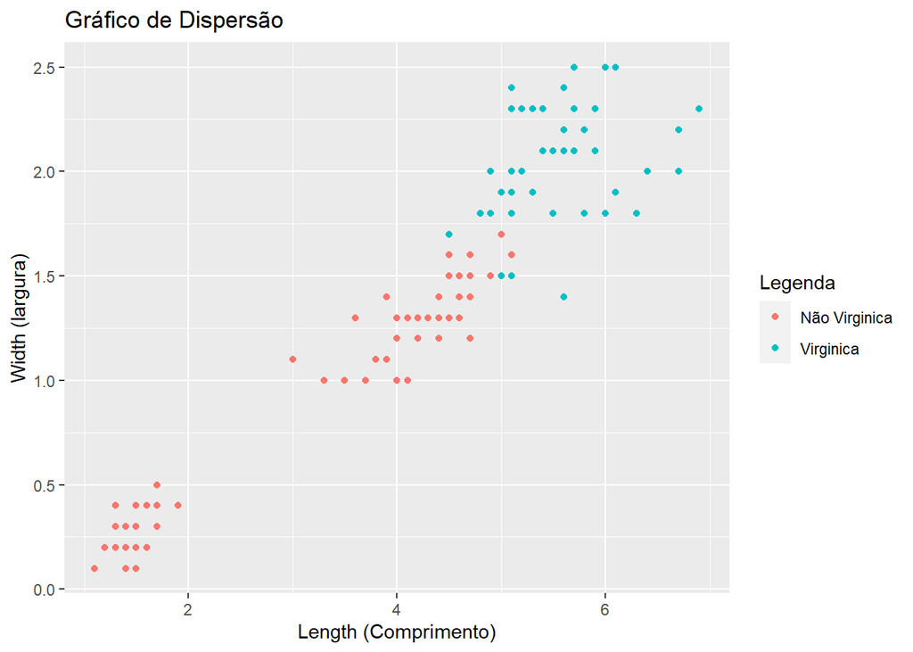

```r
ggplot(dados_treinamento, aes(x = Petal.Length, y = Petal.Width, color=Species)) +
  geom_point() +
  scale_color_discrete(name = "Legenda", labels = c("Não Virginica", "Virginica"))+
  ylab('Width (largura)') +
  xlab('Length (Comprimento)') +
  ggtitle("Gráfico de Dispersão")
```

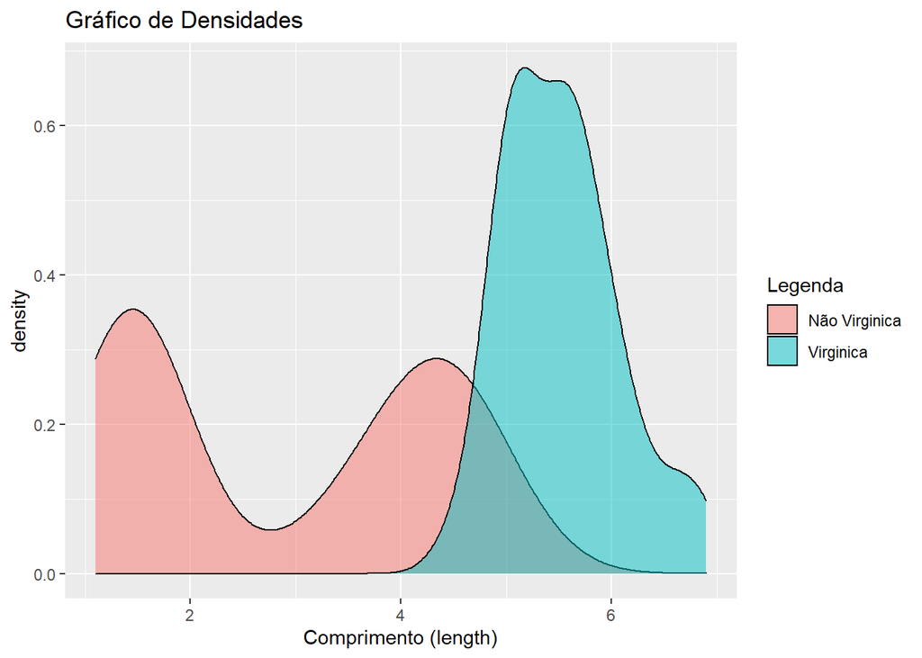

```r
ggplot(data = dados_treinamento, aes(x=Petal.Length, fill= Species)) +
  geom_density(alpha=.5) +
  xlab('Comprimento (length)') +
  scale_fill_discrete(name = "Legenda", labels = c("Não Virginica","Virginica")) +
  ggtitle("Gráfico de Densidades")
```